# Assignment 2

Ufuk Cem Birbiri

15.11.2022

# PART-1

### Comparison of imputation methods

Installing libraries

```r
#install.packages("VIM")
library(VIM)
data(SBS5242)
XNA <- SBS5242
```

Before starting the questions, let’s investigate the dataset.

```r
head(XNA)
```

```
##            PW       BWS_F      Umsatz         PERSA       BEZWD     BEZWDVK
## 1 43888.85242 35081.07414 3737.974701 11815.3610831 37577.19455 379.0521485
## 2  1449.40170  1239.13170  120.099200     5.9457950  1251.43080   8.6653528
## 3  1009.61541   944.93722   79.832300   163.2859277   857.75827   4.2969994
## 4  1218.17072   942.29390  104.851729     1.9011026  1063.73052  20.4941952
## 5   517.36342   450.46195   41.326691    18.0060038   448.09227   2.0590045
## 6    67.19103    44.91809    5.003297    -0.6017785    62.71034  -0.2673511
##       BESCH         USB      ISACH
## 1 310.09482 30.48368699 6575.33408
## 2  18.47358 -0.41414050   58.02441
## 3  24.73831  0.35008017   12.33191
## 4  30.44422 -0.37563076  513.91041
## 5  20.18175 -0.09648481   21.44578
## 6  13.85199 -0.68410116   25.90378
```

And we can see the dimension:

```r
dim(XNA)
```

```
## [1] 262   9
```

The dimensoin of the dataset is (262, 9) . We can also display the column names:

```r
colnames(XNA)
```

```
## [1] "PW"      "BWS_F"   "Umsatz"  "PERSA"   "BEZWD"   "BEZWDVK" "BESCH"
## [8] "USB"     "ISACH"
```

### Question 1

- Visualize the missing values with the function **aggr** of the **VIM** package and compute the global percentage of missing values in the dataset.

The function “aggr” measures the number of missing entries in each feature and for certain combinations of features (which tend to be missing simultaneously).

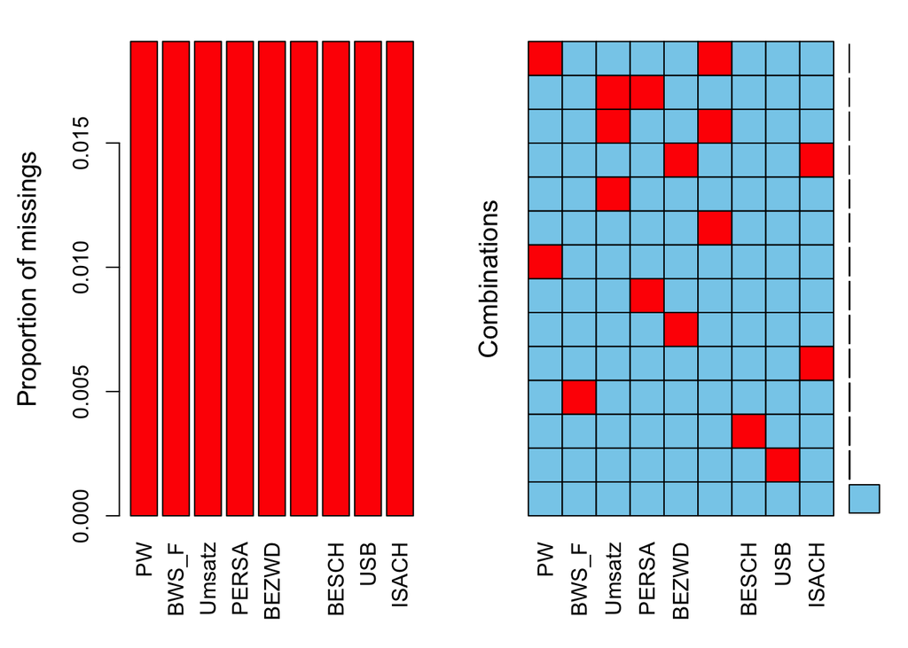

```r
## Finding missing values
a <- aggr(XNA)
```

The count of missing values and the percantage is shown in below:

```r
summary(a)
```

```
##
##  Missings per variable:
##  Variable Count
##        PW     5
##     BWS_F     5
##    Umsatz     5
##     PERSA     5
##     BEZWD     5
##   BEZWDVK     5
##     BESCH     5
##       USB     5
##     ISACH     5
##
##  Missings in combinations of variables:
##       Combinations Count    Percent
##  0:0:0:0:0:0:0:0:0   221 84.3511450
##  0:0:0:0:0:0:0:0:1     4  1.5267176
##  0:0:0:0:0:0:0:1:0     5  1.9083969
##  0:0:0:0:0:0:1:0:0     5  1.9083969
##  0:0:0:0:0:1:0:0:0     3  1.1450382
##  0:0:0:0:1:0:0:0:0     4  1.5267176
##  0:0:0:0:1:0:0:0:1     1  0.3816794
##  0:0:0:1:0:0:0:0:0     4  1.5267176
##  0:0:1:0:0:0:0:0:0     3  1.1450382
##  0:0:1:0:0:1:0:0:0     1  0.3816794
##  0:0:1:1:0:0:0:0:0     1  0.3816794
##  0:1:0:0:0:0:0:0:0     5  1.9083969
##  1:0:0:0:0:0:0:0:0     4  1.5267176
##  1:0:0:0:0:1:0:0:0     1  0.3816794
```

### Question 2

- Introduce 30% synthetic missing values in the dataset. You can use the function **synthetic_MCAR** (defined below) or create your own function. Explain why the synthetic missing values introduced as such are MCAR.

With Mcar function, the values are randomly missing from your dataset. Missing data values do not relate to any other data in the dataset and there is no pattern to the actual values of the missing data themselves.

```r
#Introduce 30% synthetic missing values in the dataset.

library(FactoMineR)
n <- dim(XNA)[1]
d <- dim(XNA)[2]

prop.miss <- 0.3
nb.miss <- floor(n*d*prop.miss)
missing_pattern.mcar <- matrix(runif(n*d,0,1) < 0.3,nrow=n,ncol=d)
XNA.mcar <- XNA
XNA.mcar[missing_pattern.mcar] <- NA
head(XNA.mcar)
```

```
##          PW     BWS_F      Umsatz       PERSA      BEZWD     BEZWDVK    BESCH
## 1        NA        NA 3737.974701          NA 37577.1945 379.0521485       NA
## 2        NA 1239.1317          NA   5.9457950  1251.4308   8.6653528 18.47358
## 3        NA        NA   79.832300 163.2859277   857.7583   4.2969994       NA
## 4 1218.1707  942.2939          NA   1.9011026         NA  20.4941952       NA
## 5  517.3634  450.4620          NA          NA   448.0923          NA       NA
## 6        NA        NA    5.003297  -0.6017785         NA  -0.2673511 13.85199
##           USB      ISACH
## 1 30.48368699 6575.33408
## 2 -0.41414050   58.02441
## 3          NA         NA
## 4 -0.37563076  513.91041
## 5 -0.09648481   21.44578
## 6 -0.68410116   25.90378
```

```r
XNA.mcar <- as.matrix(as.data.frame(XNA.mcar))
```

### Question 3

- Compare three imputation methods (mean imputation, another single imputation, multiple imputation) by computing the MSE for the synthetic missing values.

#### 3.1 Imputation by the mean

```r
ImputeMean <- function(tab){
  m <- apply(tab, 2, mean, na.rm = TRUE)
  tab <- sapply(1:ncol(tab), function(x) ifelse(is.na(tab[,x]), m[x], tab[,x]))
  tab <- as.data.frame(tab)
  return(tab)
}

XNA.mean <- ImputeMean(XNA.mcar)
head(XNA.mean)
```

```
##          V1        V2          V3           V4         V5          V6       V7
## 1 2121.9175 1312.3989 3737.974701 3387.4438433 37577.1945 379.0521485 18.07521
## 2 2121.9175 1239.1317 1958.783053    5.9457950  1251.4308   8.6653528 18.47358
## 3 2121.9175 1312.3989   79.832300  163.2859277   857.7583   4.2969994 18.07521
## 4 1218.1707  942.2939 1958.783053    1.9011026  1466.6786  20.4941952 18.07521
## 5  517.3634  450.4620 1958.783053 3387.4438433   448.0923  20.0064612 18.07521
## 6 2121.9175 1312.3989    5.003297   -0.6017785  1466.6786  -0.2673511 13.85199
##            V8         V9
## 1 30.48368699 6575.33408
## 2 -0.41414050   58.02441
## 3 12.47908099  190.23462
## 4 -0.37563076  513.91041
## 5 -0.09648481   21.44578
## 6 -0.68410116   25.90378
```

#### 3.2 Imputation with softImpute

For softImpute, the main arguments are the following ones:

- `x`: the dataset with missing values (matrix).
- `rank.max`: the restricted rank of the solution, which should not be bigger than min(dim(x))-1.
- `lambda`: the nuclear-norm regularization parameter.

```r
library(softImpute)
sft <- softImpute(x = XNA.mcar, rank.max = 4, lambda = 0.001)
XNA.sft <- sft$u %*% diag(sft$d) %*% t(sft$v) # compute the factorization
XNA.sft[which(!is.na(XNA.mcar))] <- XNA.mcar[which(!is.na(XNA.mcar))] # replace missing values by computed values
head(XNA.sft)
```

```
##             [,1]       [,2]        [,3]         [,4]       [,5]        [,6]
## [1,] -12534.5300 31946.6285 3737.974701 9366.6338965 37577.1945 379.0521485
## [2,]    764.3377  1239.1317  188.732187    5.9457950  1251.4308   8.6653528
## [3,]   -145.8643   744.8090   79.832300  163.2859277   857.7583   4.2969994
## [4,]   1218.1707   942.2939  273.168946    1.9011026   963.7718  20.4941952
## [5,]    517.3634   450.4620 -118.301865  374.9893078   448.0923   4.3574264
## [6,]   -100.9003   159.0369    5.003297   -0.6017785   190.8406  -0.2673511
##            [,7]        [,8]       [,9]
## [1,] 302.669351 30.48368699 6575.33408
## [2,]  18.473580 -0.41414050   58.02441
## [3,]   7.253866  0.65589236  120.30784
## [4,]  11.423001 -0.37563076  513.91041
## [5,]   5.283607 -0.09648481   21.44578
## [6,]  13.851994 -0.68410116   25.90378
```

#### 3.3 Imputation with multiple imputation

The parameters of the mice function is:

1. `data`: the dataset with missing values.
2. `m`: number of multiple imputations.

```r
library(mice)
nb_imputeddataset <- 5
mice_mice <- mice(data = matrix(XNA.mcar,nrow=n,ncol=d), m = nb_imputeddataset)
```

```r
IMP <- 0
for (i in 1:nb_imputeddataset) { IMP <- IMP + mice::complete(mice_mice, i)}
XNA.mice  <-  IMP/nb_imputeddataset  #5 is the default number of multiple imputations
head(XNA.mice)
```

```
##           V1         V2          V3           V4         V5          V6
## 1 12434.4730 10736.0751 3737.974701 3284.9874608 37577.1945 379.0521485
## 2  1954.0656  1239.1317 1301.193005    5.9457950  1251.4308   8.6653528
## 3   843.6446   886.7665   79.832300  163.2859277   857.7583   4.2969994
## 4  1218.1707   942.2939  424.575703    1.9011026  1937.9741  20.4941952
## 5   517.3634   450.4620  418.131783   57.0617200   448.0923   1.7566659
## 6   389.2961   373.1734    5.003297   -0.6017785   304.9218  -0.2673511
##         V7          V8         V9
## 1 88.18758 30.48368699 6575.33408
## 2 18.47358 -0.41414050   58.02441
## 3 27.46414  0.51077260   62.67022
## 4 26.22812 -0.37563076  513.91041
## 5 12.38573 -0.09648481   21.44578
## 6 13.85199 -0.68410116   25.90378
```

```r
MSE <- function(X1, X2){

  return(sqrt(mean( (X1 - X2)^2 ,na.rm=T) ) )

  }
```

```r
mse_mean <- MSE(XNA, as.matrix(XNA.mean))
mse_mean
```

```
## [1] 2469.424
```

```r
mse_soft <- MSE(XNA, as.matrix(XNA.sft))
mse_soft
```

```
## [1] 2483.65
```

```r
mse_mice <- MSE(XNA, as.matrix(XNA.mice))
mse_mice
```

```
## [1] 1981.229
```

The mean squared error is lowest in multiple imputation method.

### Question 4

- To analyse the stochasticity implied by the introduction of missing values, repeat the procedure (introduction of synthetic missing values and imputation) several times and plot the distribution of the MSEs by showing a boxplot.

#### 4.1 Repeating the experiments

I created a for-loop below to repeat the experiments 100 times. In each iteration, I introduce the missing values with 30% in the dataset, do the 3 different imputation methods and calculate the MSE, separately for each imputation methods. After this for-loop, I create a data-frame that contains the MSE’s for each imputation method. At the end I plot the box-plot of three different imputation methods.

Now let’s do the experiment 100 times and save the MSE’s:

```r
#30% missing value
prop.miss <- 0.3

mean_impt = c()
soft_impt = c()
multip_impt = c()
index = c()

for (i in 1:100) {

  #Introduce missing values and percentage
  nb.miss <- floor(n*d*prop.miss)
  missing_pattern.mcar <- matrix(runif(n*d,0,1) < 0.3,nrow=n,ncol=d)
  XNA.mcar <- XNA
  XNA.mcar[missing_pattern.mcar] <- NA
  XNA.mcar <- as.matrix(as.data.frame(XNA.mcar))

  #Mean imputation:
  XNA.mean <- ImputeMean(XNA.mcar)

  #calculate MSE
  mse_mean <- MSE(XNA, as.matrix(XNA.mean))
  mean_impt <- append(mean_impt, mse_mean)

  #Soft Imputation:
  sft <- softImpute(x = XNA.mcar, rank.max = 4, lambda = 0.001)
  XNA.sft <- sft$u %*% diag(sft$d) %*% t(sft$v)
  XNA.sft[which(!is.na(XNA.mcar))] <- XNA.mcar[which(!is.na(XNA.mcar))]

  #calculate MSE
  mse_soft <- MSE(XNA, as.matrix(XNA.sft))
  soft_impt <- append(soft_impt, mse_soft)

  #Multiple imputation
  nb_imputeddataset <- 5
  mice_mice <- mice(data = matrix(XNA.mcar,nrow=n,ncol=d), m = nb_imputeddataset)
  IMP <- 0
  for (i in 1:nb_imputeddataset) { IMP <- IMP + mice::complete(mice_mice, i)}
  XNA.mice  <-  IMP/nb_imputeddataset  #5 is the default number of multiple imputations

  #calculate MSE
  mse_mice <- MSE(XNA, as.matrix(XNA.mice))
  multip_impt <- append(multip_impt, mse_mice)

  #Index:
  #I also save the index to use it in the box-plot later as the x-axis
  index <- append(index, i)
}
```

Create the data-frame:

```r
data <- data.frame(
  name=c( index  ),
  mean_impt=c( mean_impt),
  soft_impt=c( soft_impt),
  multip_impt = c(multip_impt)
)
```

#### 4.2 Mean imputation Box-Plot

Let’s plot the mean imputation box-plot

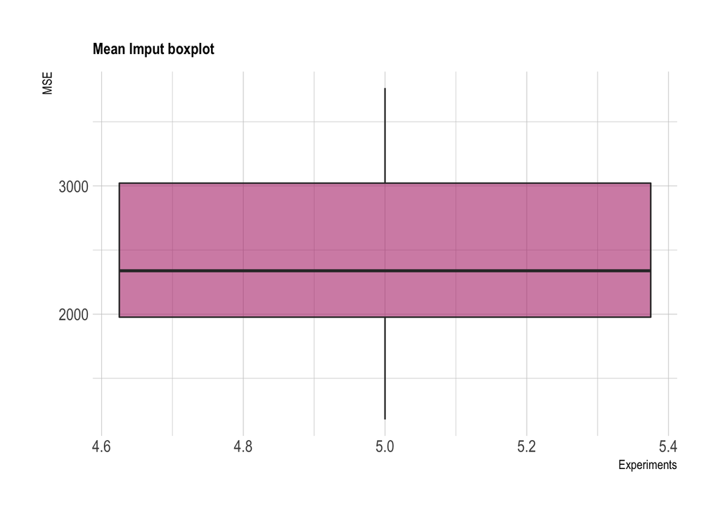

```r
# Libraries
library(tidyverse)
library(hrbrthemes)
library(viridis)



data %>%
  ggplot( aes(x=name, y=mean_impt, fill=name)) +
    geom_boxplot() +
    scale_fill_viridis(discrete = 0, alpha=0.6, option="A") +
    theme_ipsum() +
    theme(
      legend.position="none",
      plot.title = element_text(size=11)
    ) +
    ggtitle("Mean Imput boxplot") +
    xlab("Experiments")+ ylab("MSE")
```

#### 4.3 SOFT imputation Box-Plot

Plot the Soft imputation box-plot.

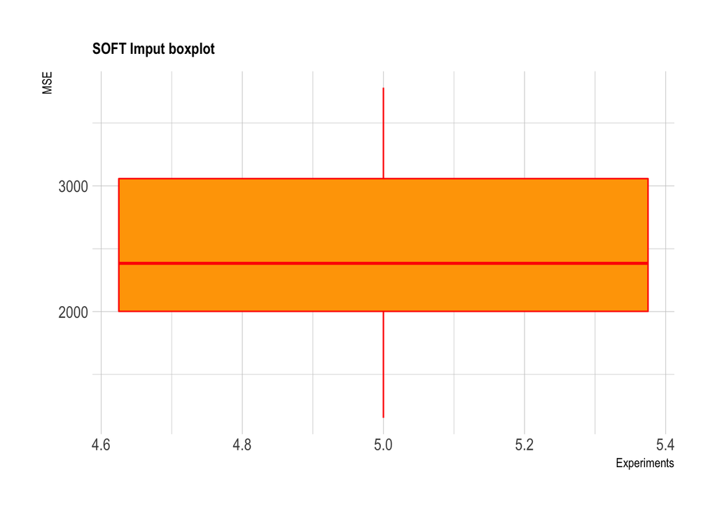

```r
data %>%
  ggplot( aes(x=name, y=soft_impt, fill=name)) +
    geom_boxplot(color="red", fill="orange") +
    scale_fill_viridis(discrete = 0, alpha=0.6, option="A") +

    theme_ipsum() +
    theme(
      legend.position="none",
      plot.title = element_text(size=11)
    ) +
    ggtitle("SOFT Imput boxplot") +
    xlab("Experiments")+ ylab("MSE")
```

#### 4.3 Multiple imputation Box-Plot

At the end, let’s plot the multiple imputation box-plot

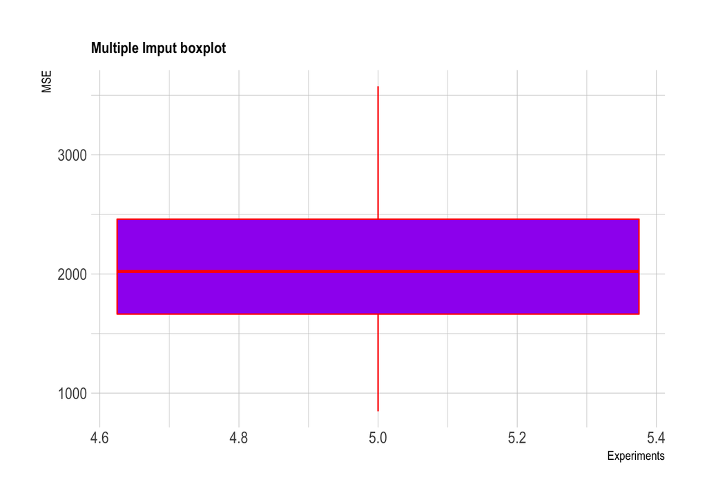

```r
data %>%
  ggplot( aes(x=name, y=multip_impt, fill=name)) +
    geom_boxplot(color="red", fill="purple") +
    scale_fill_viridis(discrete = 0, alpha=0.6, option="A") +

    theme_ipsum() +
    theme(
      legend.position="none",
      plot.title = element_text(size=11)
    ) +
    ggtitle("Multiple Imput boxplot") +
    xlab("Experiments")+ ylab("MSE")
```